# Section 3.1: Turing Machines, continued

# Recognizing vs. Deciding

## Simple Turing Machine example

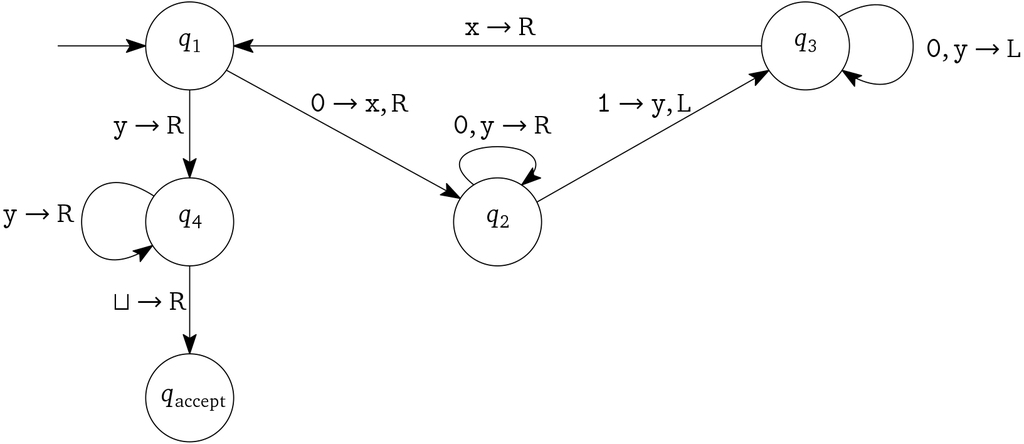

## Equivalent TM?

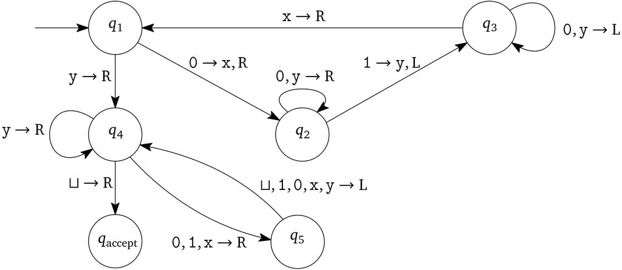

## Recognizing and Deciding

- A TM **recognizes** a language $A$ if the set of strings that it accepts is the set $A$. (*Recognizers* might have infinite loops.)
- A TM **decides** $A$ if it accepts every string that is in $A$ and rejects every string that is not in $A$. (*Deciders* always *halt*.)

If a language has a decider, it is called **decidable**.

## Decider for $A = \{\mathtt{0}^{2^n}\}$

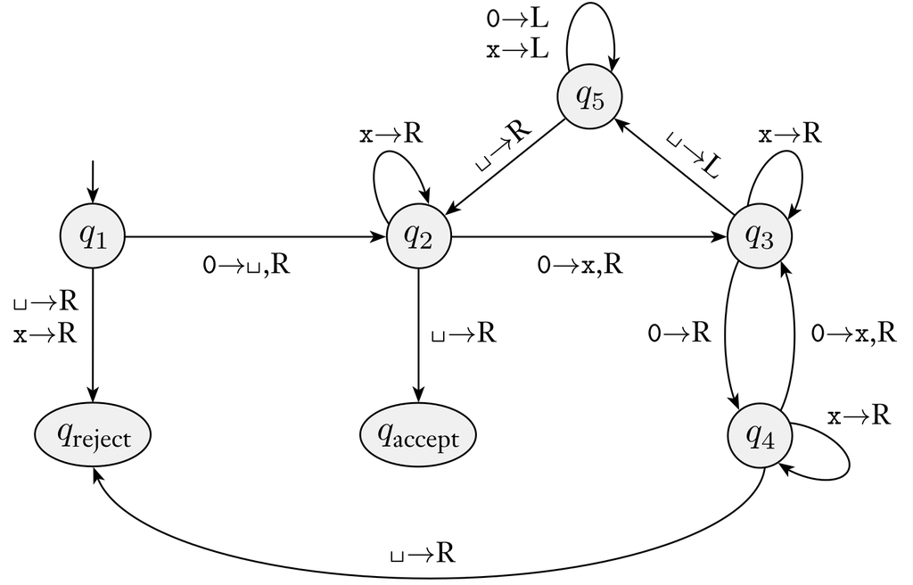

# More TM examples

## Implementation descriptions

- Say how the tape is processed.
- Don’t need to enumerate all the states.
- You have enough detail if someone can follow your description and process a tape.
- Each step must only accomplish a finite amount of work, though there is no bound on the amount of tape used.

## Multiplication checker

Decider for $C = \{\mathtt{a}^i\mathtt{b}^j\mathtt{c}^k \mid ij = k \text{ and } i,j,k \geq 1\}$

## $\{\mathtt{a}^i\mathtt{b}^j\mathtt{c}^k \mid ij = k \text{ and } i,j,k \geq 1\}$

1. Scan tape from left to right to check that input is of the form $\mathtt{a}^+\mathtt{b}^+\mathtt{c}^+$. If not, reject.
2. Return to front of tape.
3. $\mathtt{x}$-out an $\mathtt{a}$. Scan right to the next $\mathtt{b}$. Alternately mark $\mathtt{b}$’s and $\mathtt{c}$, moving left and right as you go, until no more unmarked $\mathtt{b}$’s remain. (By “mark”, we mean replace $\mathtt{b}$ with the symbol $\stackrel{\bullet}{\mathtt{b}}$). If you run out of $\mathtt{c}$’s, reject.
4. Remove the marks, go back to the first $\mathtt{a}$, and repeat step 3, until all $\mathtt{a}$’s are gone. If $\mathtt{c}$’s remain, reject. Otherwise, accept.

## Distinct string checker

Decider for $E = \{\mathtt{\#}x_1\mathtt{\#}x_2\mathtt{\#}\cdots\mathtt{\#}x_l \mid x_i \in \{\mathtt{0}, \mathtt{1}\}^\ast \text{ and } x_i \neq x_j \text{ for } i\neq j\}$

## $\{\mathtt{\#}x_1\mathtt{\#}x_2\mathtt{\#}\cdots\mathtt{\#}x_l \mid x_i \in \{\mathtt{0}, \mathtt{1}\}^\ast \text{ and } x_i \neq x_j \text{ for } i\neq j\}$

1. If the first symbol is $\mathtt{\#}$, mark it. (If blank, accept. Else reject.)
2. Move right on the tape and mark the next $\mathtt{\#}$.
3. Move back and forth, comparing the two strings after the marked $\mathtt{\#}$’s. If they match reject.
4. Unmark the second marked $\mathtt{\#}$ and mark the next $\mathtt{\#}$. Then repeat 3. Keep moving the second marked $\mathtt{\#}$ and repeating 3 until you reach the last marked $\mathtt{\#}$.
5. Unmark the first marked $\mathtt{\#}$ and mark the next $\mathtt{\#}$. Then unmark the second marked $\mathtt{\#}$ and mark the first $\mathtt{\#}$ after the first marked $\mathtt{\#}$. Go to 3.
6. If you run out of room in step 5, accept.